# BILGER-HANS-ADA-HOMEWORK-04

Hans Bilger

April 14, 2019

### David Ledesma and I worked together on this homework assignment.

#### Load in Kamilar and Cooper data

```r
library(readr)
d <- read_csv("KamilarAndCooper")
head(d)
```

```
## # A tibble: 6 x 44
##   Scientific_Name Family Genus Species Brain_Size_Spec… Brain_Size_Fema…
##   <chr>           <chr>  <chr> <chr>              <dbl>            <dbl>
## 1 Allenopithecus… Cerco… Alle… nigrov…             58.0             53.7
## 2 Allocebus_tric… Cerco… Allo… tricho…             NA               NA
## 3 Alouatta_belze… Ateli… Alou… belzeb…             52.8             51.2
## 4 Alouatta_caraya Ateli… Alou… caraya              52.6             47.8
## 5 Alouatta_guari… Ateli… Alou… guariba             51.7             49.1
## 6 Alouatta_palli… Ateli… Alou… pallia…             49.9             48.0
## # … with 38 more variables: Brain_size_Ref <chr>,
## #   Body_mass_male_mean <dbl>, Body_mass_female_mean <dbl>,
## #   Mass_Dimorphism <dbl>, Mass_Ref <chr>, MeanGroupSize <dbl>,
## #   AdultMales <dbl>, AdultFemale <dbl>, AdultSexRatio <dbl>,
## #   Social_Organization_Ref <chr>, InterbirthInterval_d <dbl>,
## #   Gestation <dbl>, WeaningAge_d <dbl>, MaxLongevity_m <dbl>,
## #   LitterSz <dbl>, Life_History_Ref <chr>, GR_MidRangeLat_dd <dbl>,
## #   Precip_Mean_mm <dbl>, Temp_Mean_degC <dbl>, AET_Mean_mm <dbl>,
## #   PET_Mean_mm <dbl>, Climate_Ref <chr>, HomeRange_km2 <dbl>,
## #   HomeRangeRef <chr>, DayLength_km <dbl>, DayLengthRef <chr>,
## #   Territoriality <dbl>, Fruit <dbl>, Leaves <chr>, Fauna <chr>,
## #   DietRef1 <chr>, Canine_Dimorphism <dbl>, Canine_Dimorphism_Ref <chr>,
## #   Feed <dbl>, Move <dbl>, Rest <dbl>, Social <dbl>,
## #   Activity_Budget_Ref <chr>
```

#### [1] Using the “KamilarAndCooperData.csv” dataset, run a linear regression looking at log(HomeRange_km2) in relation to log(Body_mass_female_mean) and report your β coeffiecients (slope and intercept).

```r
model <- lm(data=d, log(HomeRange_km2)~log(Body_mass_female_mean))
summary(model)
```

```
##
## Call:
## lm(formula = log(HomeRange_km2) ~ log(Body_mass_female_mean),
##     data = d)
##
## Residuals:
##     Min      1Q  Median      3Q     Max
## -3.3929 -0.9433 -0.0126  1.0944  3.6826
##
## Coefficients:
##                            Estimate Std. Error t value Pr(>|t|)
## (Intercept)                -9.44123    0.67293  -14.03   <2e-16 ***
## log(Body_mass_female_mean)  1.03643    0.08488   12.21   <2e-16 ***
## ---
## Signif. codes:  0 '***' 0.001 '**' 0.01 '*' 0.05 '.' 0.1 ' ' 1
##
## Residual standard error: 1.423 on 135 degrees of freedom
##   (76 observations deleted due to missingness)
## Multiple R-squared:  0.5248, Adjusted R-squared:  0.5213
## F-statistic: 149.1 on 1 and 135 DF,  p-value: < 2.2e-16
```

```r
model$coefficients
```

```
##                (Intercept) log(Body_mass_female_mean)
##                  -9.441231                   1.036432
```

```r
coef(summary(model))[1,1]
```

```
## [1] -9.441231
```

```r
# b0 (intercept) = -9.44
# b1 (slope) = 1.036
```

#### [2] Then, use bootstrapping to sample from your data 1000 times with replacement, each time fitting the same model and calculating the appropriate coefficients. [The size of each sample should be equivalent to the number of observations in your dataset.] This generates a sampling distribution for each β coefficient. Plot a histogram of these sampling distributions.

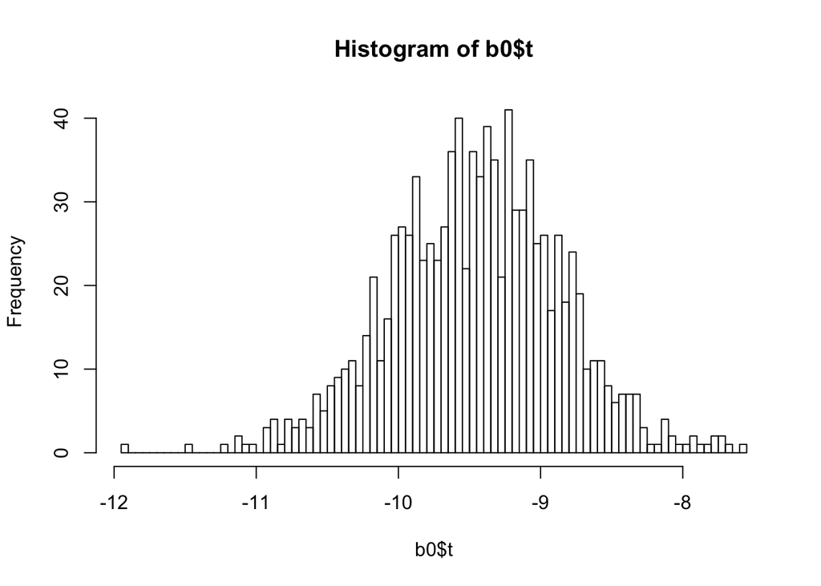

```r
# b0 histogram
library(boot)
library(tidyverse)
s <- function(data,formula){
    sim = sample_n(d, 213, replace = TRUE)
    return(lm(data=sim, log(HomeRange_km2)~log(Body_mass_female_mean))$coef[1])
}
b0 <- boot(data=d, statistic=s, R=1000)
hist(b0$t, breaks = 100)
```

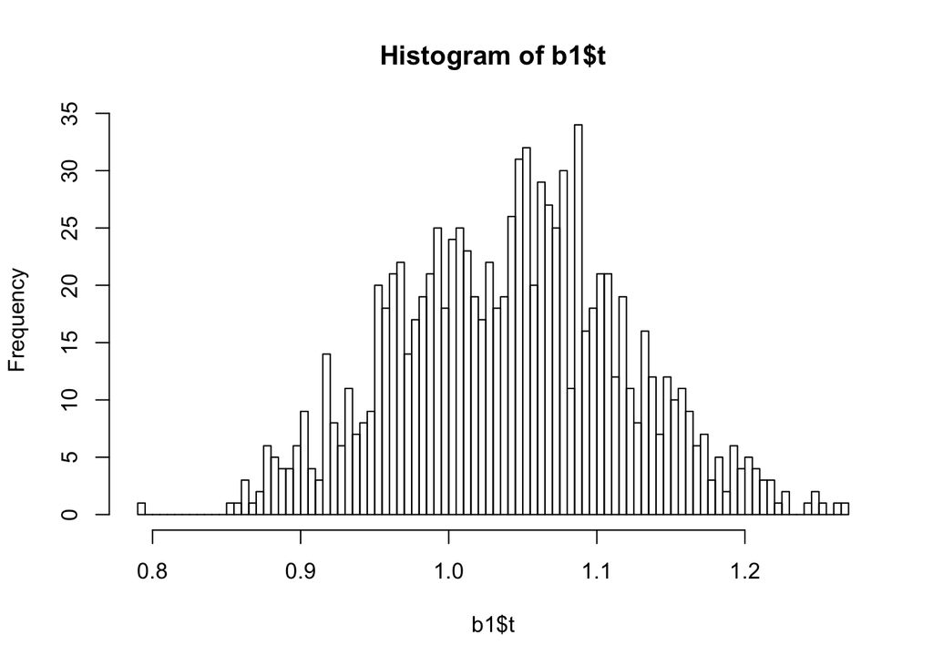

```r
#b1 histogram
s <- function(data,formula){
    sim = sample_n(d, 213, replace = TRUE)
    return(lm(data=sim, log(HomeRange_km2)~log(Body_mass_female_mean))$coef[2])
    }
b1 <- boot(data=d, statistic=s, R=1000)
hist(b1$t, breaks = 100)
```